# 06_Tratamiento_Features_Categoricas

[figure not shown]

*NOTA: [Adaptado de "Hands-On Machine Learning with Scikit-Learn, Kera, and Tensorflow" de Aurelien Geron]*

## ML INTRO PRACTICA (III): Preparación de Features Categóricas

```python
# Recuperemos lo hecho en la sesión anterior

import matplotlib.pyplot as plt
import numpy as np
import pandas as pd
import seaborn as sns

from bootcampviztools import pinta_distribucion_categoricas, plot_categorical_numerical_relationship, plot_grouped_histograms
from sklearn.model_selection import train_test_split


# Código extra para los tamaños de las fuentes y los "ticks" de los ejes, esto no lo vimos al hablar de matplotlib así que una extra
plt.rc('font', size=14)
plt.rc('axes', labelsize=14, titlesize=14)
plt.rc('legend', fontsize=14)
plt.rc('xtick', labelsize=10)
plt.rc('ytick', labelsize=10)


df_inmo = pd.read_csv("./data/ejemplo_housing.csv")

train_set, test_set = train_test_split(df_inmo, test_size=0.2, random_state=42)

train_set["income_cat"] = pd.cut(train_set["median_income"],
                               bins=[0., 1.5, 3.0, 4.5, 6., np.inf],
                               labels=[1, 2, 3, 4, 5])

train_set["rooms_per_house"] = train_set["total_rooms"] / train_set["households"]
train_set["bedrooms_ratio"] = train_set["total_bedrooms"] / train_set["total_rooms"]

features = ["ocean_proximity", "income_cat", "rooms_per_house","total_rooms","housing_median_age","bedrooms_ratio"]

target = "median_house_value"
```

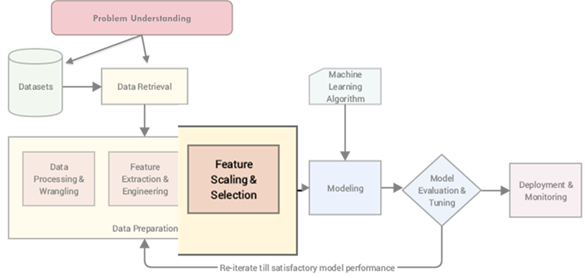

### 1. Tratamiento de variables categóricas

```python
train_set.info()
```

```
<class 'pandas.core.frame.DataFrame'>
Index: 16346 entries, 17560 to 15795
Data columns (total 13 columns):
 #   Column              Non-Null Count  Dtype
---  ------              --------------  -----
 0   longitude           16346 non-null  float64
 1   latitude            16346 non-null  float64
 2   housing_median_age  16346 non-null  float64
 3   total_rooms         16346 non-null  float64
 4   total_bedrooms      16346 non-null  float64
 5   population          16346 non-null  float64
 6   households          16346 non-null  float64
 7   median_income       16346 non-null  float64
 8   median_house_value  16346 non-null  float64
 9   ocean_proximity     16346 non-null  object
 10  income_cat          16346 non-null  category
 11  rooms_per_house     16346 non-null  float64
 12  bedrooms_ratio      16346 non-null  float64
dtypes: category(1), float64(11), object(1)
memory usage: 1.6+ MB
```

Para poder aplicar los algoritmos de generación de modelos necesitamos convertir las categorías o valores de las variables categóricas en números de alguna forma. Vamos a ver dos para transformar "ocean_proximity" e "income_cat" que tiene el tipo category (que algunos algoritmos maneja pero otros no)

#### 1.1 Ordinal Encoding

Una primera forma de convertir los valores de una categoría es utilizar un "codificador ordinal" o "Ordinal Encoder" que convertira cada valor de la categoría en un número entero. El problema es que automáticamente se establece una relación de orden que no necesariamente tiene por qué existir:

```python
from sklearn.preprocessing import OrdinalEncoder

ordinal_encoder = OrdinalEncoder()
train_set["ordinal_ocean"] = ordinal_encoder.fit_transform(train_set[["ocean_proximity"]])
```

```python
train_set[["ordinal_ocean","ocean_proximity"]].sample(10)
```

|  | ordinal_ocean | ocean_proximity |
| --- | --- | --- |
| 14899 | 0.0 | <1H OCEAN |
| 11163 | 4.0 | NEAR OCEAN |
| 13975 | 0.0 | <1H OCEAN |
| 10036 | 0.0 | <1H OCEAN |
| 18688 | 0.0 | <1H OCEAN |
| 15912 | 4.0 | NEAR OCEAN |
| 16083 | 0.0 | <1H OCEAN |
| 676 | 4.0 | NEAR OCEAN |
| 17626 | 4.0 | NEAR OCEAN |
| 9505 | 1.0 | INLAND |

```python
ordinal_encoder.categories_
```

```
[array(['<1H OCEAN', 'INLAND', 'ISLAND', 'NEAR BAY', 'NEAR OCEAN'],
       dtype=object)]
```

El caso de "ocean_proximity" quizá sea de esos en los que establecer un orden no sea ni claro ni oscuro, ni sí ni no, porque si hay una relación de distancia al mar. Pero tendríamos que forzarlo

```python
categories = [["ISLAND","NEAR OCEAN","NEAR BAY","<1H OCEAN","INLAND"]]
ordinal_encoder = OrdinalEncoder(categories= categories)
train_set["ordinal_ocean"] = ordinal_encoder.fit_transform(train_set[["ocean_proximity"]])
```

```python
train_set.ordinal_ocean.value_counts()
```

```
ordinal_ocean
3.0    7219
4.0    5212
1.0    2101
2.0    1810
0.0       4
Name: count, dtype: int64
```

En el caso de "income_cat" tiene más sentido porque en sí es una categórica ordinal:

```python
train_set.income_cat.value_counts()
```

```
income_cat
3    5771
2    5182
4    2892
5    1847
1     654
Name: count, dtype: int64
```

No vamos a tocarla, si es necesario para los algoritmos que usemos cambiaremos el tipo sobre la marcha.

#### 1.2 One-Hot Encoding

Cuando no estamos seguros o no queremos convertir una variable categórica en una variable ordinal numérica, una alternativa es hacer lo que hicimos con los géneros de las películas en el sprint dedicado al Algebra y Numpy [si hace miles de años] que convertíamos cada valor categórico en un 1 o un cero dentro de un vector. Sólo que ahora no es un vector sino que cada valor posible de la variable categórica se va a convertir en una nueva columna que tendrá valor 0 o 1 si la zona (la instancia) cumple con ese valor. Veámoslo

```python
pd.get_dummies(train_set, columns=["ocean_proximity"]).head()
```

|  | longitude | latitude | housing_median_age | total_rooms | total_bedrooms | population | households | median_income | median_house_value | income_cat | rooms_per_house | bedrooms_ratio | ordinal_ocean | ocean_proximity_<1H OCEAN | ocean_proximity_INLAND | ocean_proximity_ISLAND | ocean_proximity_NEAR BAY | ocean_proximity_NEAR OCEAN |
| --- | --- | --- | --- | --- | --- | --- | --- | --- | --- | --- | --- | --- | --- | --- | --- | --- | --- | --- |
| 17560 | -117.96 | 34.00 | 34.0 | 2777.0 | 540.0 | 1954.0 | 522.0 | 4.5163 | 183800.0 | 4 | 5.319923 | 0.194454 | 3.0 | True | False | False | False | False |
| 2045 | -122.81 | 38.54 | 12.0 | 2289.0 | 611.0 | 919.0 | 540.0 | 1.1553 | 139300.0 | 1 | 4.238889 | 0.266929 | 3.0 | True | False | False | False | False |
| 6383 | -122.25 | 37.77 | 52.0 | 2650.0 | 566.0 | 1468.0 | 567.0 | 3.0161 | 215700.0 | 3 | 4.673721 | 0.213585 | 2.0 | False | False | False | True | False |
| 4574 | -117.98 | 33.86 | 25.0 | 1025.0 | 266.0 | 726.0 | 183.0 | 3.8750 | 137500.0 | 3 | 5.601093 | 0.259512 | 3.0 | True | False | False | False | False |
| 15118 | -119.70 | 34.43 | 35.0 | 1402.0 | 369.0 | 654.0 | 385.0 | 2.6205 | 318800.0 | 2 | 3.641558 | 0.263195 | 3.0 | True | False | False | False | False |

```python
pd.get_dummies(train_set, columns=["ocean_proximity"], dtype= int).head()
```

|  | longitude | latitude | housing_median_age | total_rooms | total_bedrooms | population | households | median_income | median_house_value | income_cat | rooms_per_house | bedrooms_ratio | ordinal_ocean | ocean_proximity_<1H OCEAN | ocean_proximity_INLAND | ocean_proximity_ISLAND | ocean_proximity_NEAR BAY | ocean_proximity_NEAR OCEAN |
| --- | --- | --- | --- | --- | --- | --- | --- | --- | --- | --- | --- | --- | --- | --- | --- | --- | --- | --- |
| 17560 | -117.96 | 34.00 | 34.0 | 2777.0 | 540.0 | 1954.0 | 522.0 | 4.5163 | 183800.0 | 4 | 5.319923 | 0.194454 | 3.0 | 1 | 0 | 0 | 0 | 0 |
| 2045 | -122.81 | 38.54 | 12.0 | 2289.0 | 611.0 | 919.0 | 540.0 | 1.1553 | 139300.0 | 1 | 4.238889 | 0.266929 | 3.0 | 1 | 0 | 0 | 0 | 0 |
| 6383 | -122.25 | 37.77 | 52.0 | 2650.0 | 566.0 | 1468.0 | 567.0 | 3.0161 | 215700.0 | 3 | 4.673721 | 0.213585 | 2.0 | 0 | 0 | 0 | 1 | 0 |
| 4574 | -117.98 | 33.86 | 25.0 | 1025.0 | 266.0 | 726.0 | 183.0 | 3.8750 | 137500.0 | 3 | 5.601093 | 0.259512 | 3.0 | 1 | 0 | 0 | 0 | 0 |
| 15118 | -119.70 | 34.43 | 35.0 | 1402.0 | 369.0 | 654.0 | 385.0 | 2.6205 | 318800.0 | 2 | 3.641558 | 0.263195 | 3.0 | 1 | 0 | 0 | 0 | 0 |

```python
train_set_bck = train_set.copy()
train_set = pd.get_dummies(train_set, columns = ["ocean_proximity"], dtype = int)
```

Y con eso tendríamos preparadas las columnas categóricas. Es hora de "escalar" y convertir las distribuciones de las numéricas